# lecture 13

Julia Olivieri

2023-02-28

## Data set

In this report we’ll be analyzing data from the 2015 World Happiness Report.

We’ll start by reading in the data:

```r
library(tidyverse)
countries <- read_csv("~/Desktop/COMP_162/datasets/happiness_2015.csv")
```

## Exploratory data analysis

### Descriptive statistics

Let’s start by finding some summaries of our variables.

```r
summary(countries)
```

```
##    Country             Region          HappinessScore  StandardError
##  Length:158         Length:158         Min.   :2.839   Min.   :0.01848
##  Class :character   Class :character   1st Qu.:4.526   1st Qu.:0.03727
##  Mode  :character   Mode  :character   Median :5.232   Median :0.04394
##                                        Mean   :5.376   Mean   :0.04788
##                                        3rd Qu.:6.244   3rd Qu.:0.05230
##                                        Max.   :7.587   Max.   :0.13693
##   GDPperCapita        Family       LifeExpectancy      Freedom
##  Min.   :0.0000   Min.   :0.0000   Min.   :0.0000   Min.   :0.0000
##  1st Qu.:0.5458   1st Qu.:0.8568   1st Qu.:0.4392   1st Qu.:0.3283
##  Median :0.9102   Median :1.0295   Median :0.6967   Median :0.4355
##  Mean   :0.8461   Mean   :0.9910   Mean   :0.6303   Mean   :0.4286
##  3rd Qu.:1.1584   3rd Qu.:1.2144   3rd Qu.:0.8110   3rd Qu.:0.5491
##  Max.   :1.6904   Max.   :1.4022   Max.   :1.0252   Max.   :0.6697
##      Trust           Generosity
##  Min.   :0.00000   Min.   :0.0000
##  1st Qu.:0.06168   1st Qu.:0.1506
##  Median :0.10722   Median :0.2161
##  Mean   :0.14342   Mean   :0.2373
##  3rd Qu.:0.18025   3rd Qu.:0.3099
##  Max.   :0.55191   Max.   :0.7959
```

Based on this output, we can see that our quantitative variables (other than `HappinessScore`) seem to fall between 0 and 2 (so for example `LifeExpectancy` isn’t in years).

We have two categorical variables. Let’s see how many observations of each type we have for these.

```r
countries %>%
  group_by(Country) %>%
  summarize(count = n()) %>%
  arrange(desc(count))
```

```
## # A tibble: 158 × 2
##    Country     count
##    <chr>       <int>
##  1 Afghanistan     1
##  2 Albania         1
##  3 Algeria         1
##  4 Angola          1
##  5 Argentina       1
##  6 Armenia         1
##  7 Australia       1
##  8 Austria         1
##  9 Azerbaijan      1
## 10 Bahrain         1
## # … with 148 more rows
```

Looks like there’s only one entry for each country, just as we’d suspect. Let’s do the same for region:

```r
countries %>%
  group_by(Region) %>%
  summarize(count = n()) %>%
  arrange(desc(count))
```

```
## # A tibble: 10 × 2
##    Region                          count
##    <chr>                           <int>
##  1 Sub-Saharan Africa                 40
##  2 Central and Eastern Europe         29
##  3 Latin America and Caribbean        22
##  4 Western Europe                     21
##  5 Middle East and Northern Africa    20
##  6 Southeastern Asia                   9
##  7 Southern Asia                       7
##  8 Eastern Asia                        6
##  9 Australia and New Zealand           2
## 10 North America                       2
```

We can see that the five regions with the greatest number of countries contain the vast majority of countries. This could be useful if we want to subset to only specific regions later in our analysis.

Let’s break down some of these scores more. I’m interested in finding how the means of our various quantitative variables vary by region.

```r
countries %>%
  group_by(Region) %>%
  summarize(avg_score = mean(Generosity)) %>%
  arrange(desc(avg_score))
```

```
## # A tibble: 10 × 2
##    Region                          avg_score
##    <chr>                               <dbl>
##  1 Australia and New Zealand           0.455
##  2 North America                       0.430
##  3 Southeastern Asia                   0.419
##  4 Southern Asia                       0.341
##  5 Western Europe                      0.302
##  6 Eastern Asia                        0.226
##  7 Sub-Saharan Africa                  0.221
##  8 Latin America and Caribbean         0.218
##  9 Middle East and Northern Africa     0.190
## 10 Central and Eastern Europe          0.152
```

```r
countries %>%
  group_by(Region) %>%
  summarize(avg_score = mean(GDPperCapita)) %>%
  arrange(desc(avg_score))
```

```
## # A tibble: 10 × 2
##    Region                          avg_score
##    <chr>                               <dbl>
##  1 North America                       1.36
##  2 Western Europe                      1.30
##  3 Australia and New Zealand           1.29
##  4 Eastern Asia                        1.15
##  5 Middle East and Northern Africa     1.07
##  6 Central and Eastern Europe          0.942
##  7 Latin America and Caribbean         0.877
##  8 Southeastern Asia                   0.789
##  9 Southern Asia                       0.560
## 10 Sub-Saharan Africa                  0.380
```

```r
countries %>%
  group_by(Region) %>%
  summarize(avg_score = mean(Family)) %>%
  arrange(desc(avg_score))
```

```
## # A tibble: 10 × 2
##    Region                          avg_score
##    <chr>                               <dbl>
##  1 Australia and New Zealand           1.31
##  2 North America                       1.28
##  3 Western Europe                      1.25
##  4 Latin America and Caribbean         1.10
##  5 Eastern Asia                        1.10
##  6 Central and Eastern Europe          1.05
##  7 Southeastern Asia                   0.940
##  8 Middle East and Northern Africa     0.920
##  9 Sub-Saharan Africa                  0.809
## 10 Southern Asia                       0.645
```

### Exploratory visualizations

Now let’s look at some visualizations of our data. Let’s look at the relationships between our quantitative variables:

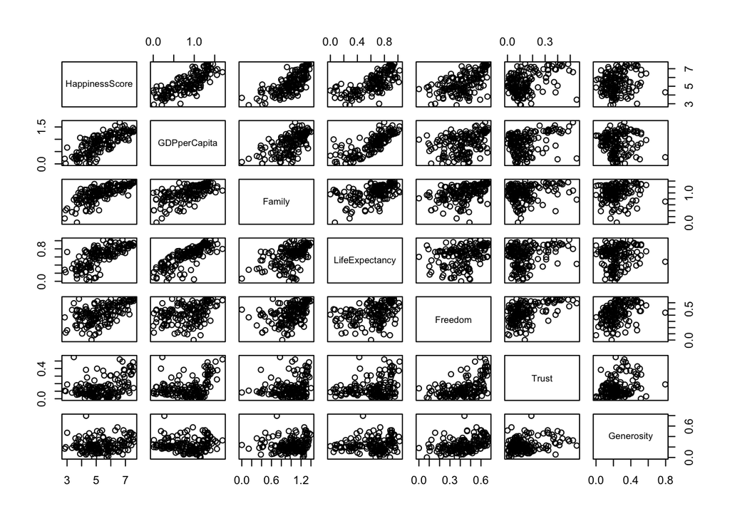

```r
countries %>%
  select(-Country, -Region, -StandardError) %>%
  pairs()
```

Looks like there are some interesting relationships here. One I’m interested in is the relationship between `GDPperCapita` and `LifeExpectancy`. Let’s see how that varies with region.

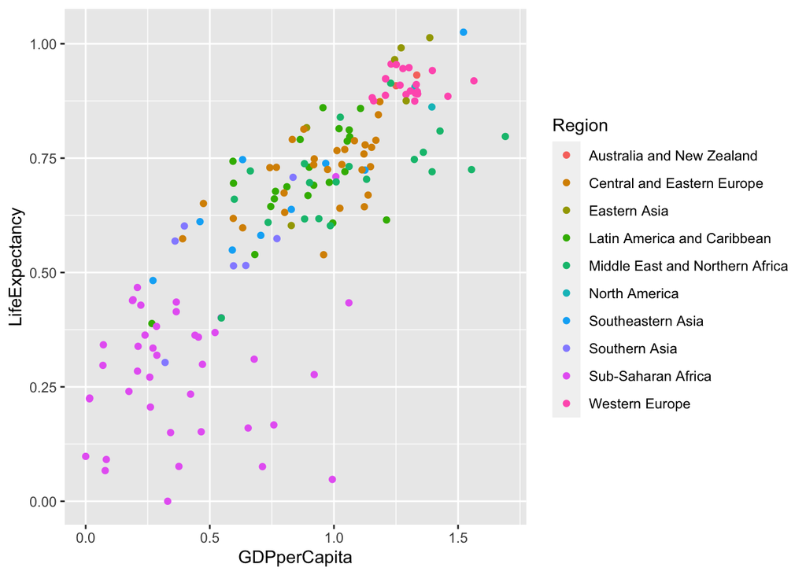

```r
ggplot(countries, aes(GDPperCapita, LifeExpectancy,color=Region)) +
  geom_point()
```

That’s interesting, it looks like the `LifeExpectancy` in Sub-Saharan Africa is lower than almost all other regions, even when the `GDPperCapita` is higher. It also looks like the Western European countries all have very high values for both.

It’s a bit hard to tell some of these colors apart. Let’s look at `GDPperCapita` separated by region:

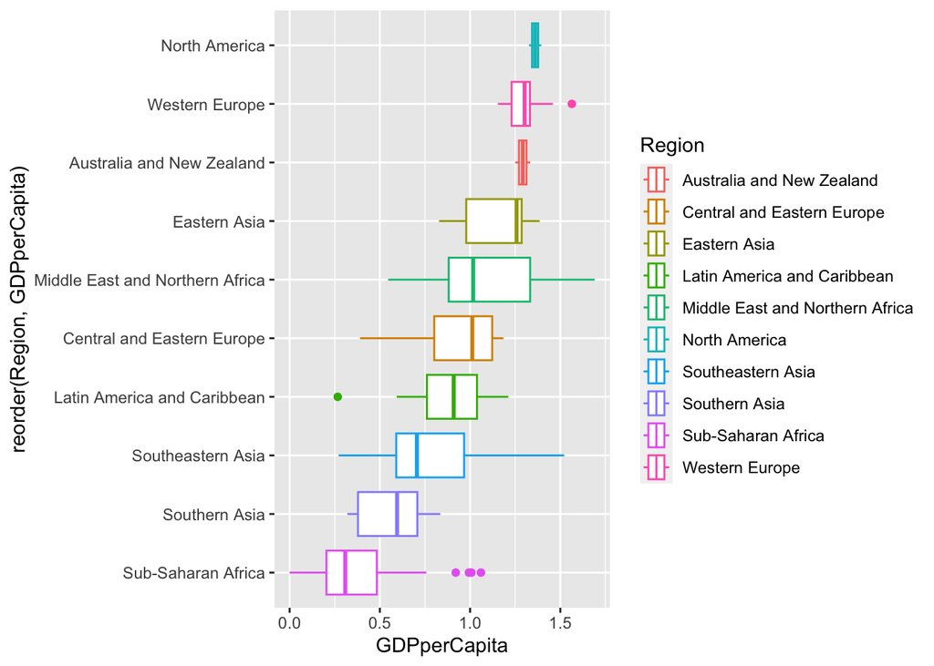

```r
ggplot(countries, aes(GDPperCapita, reorder(Region, GDPperCapita),color=Region)) +
  geom_boxplot()
```